# p8451_assignment_9

2023-03-27

### Loading packages and preparing dataset

The code below will load the data and process it.

1. Subsetting the data to only include the relevant features
2. Removing observations with missing values

From the prior assignment, the data are imbalanced, so we will need to deal with this during our analysis.

```r
library(lattice)
library(NHANES)
library(dplyr)
library(caret)
library(randomForest)
data ("NHANES")
table(NHANES$Diabetes)
```

```
##
##   No  Yes
## 9098  760
```

```r
keep.var<-names(NHANES) %in% c("Age", "Race1", "Education", "Poverty", "Weight", "Height", "Pulse", "Diabetes", "BMI", "PhysActive", "Smoke100", "BPSysAve", "BPDiaAve", "TotChol")

NHANES.subset<-NHANES[keep.var]

str(NHANES.subset)
```

```
## tibble [10,000 × 14] (S3: tbl_df/tbl/data.frame)
##  $ Age       : int [1:10000] 34 34 34 4 49 9 8 45 45 45 ...
##  $ Race1     : Factor w/ 5 levels "Black","Hispanic",..: 4 4 4 5 4 4 4 4 4 4 ...
##  $ Education : Factor w/ 5 levels "8th Grade","9 - 11th Grade",..: 3 3 3 NA 4 NA NA 5 5 5 ...
##  $ Poverty   : num [1:10000] 1.36 1.36 1.36 1.07 1.91 1.84 2.33 5 5 5 ...
##  $ Weight    : num [1:10000] 87.4 87.4 87.4 17 86.7 29.8 35.2 75.7 75.7 75.7 ...
##  $ Height    : num [1:10000] 165 165 165 105 168 ...
##  $ BMI       : num [1:10000] 32.2 32.2 32.2 15.3 30.6 ...
##  $ Pulse     : int [1:10000] 70 70 70 NA 86 82 72 62 62 62 ...
##  $ BPSysAve  : int [1:10000] 113 113 113 NA 112 86 107 118 118 118 ...
##  $ BPDiaAve  : int [1:10000] 85 85 85 NA 75 47 37 64 64 64 ...
##  $ TotChol   : num [1:10000] 3.49 3.49 3.49 NA 6.7 4.86 4.09 5.82 5.82 5.82 ...
##  $ Diabetes  : Factor w/ 2 levels "No","Yes": 1 1 1 1 1 1 1 1 1 1 ...
##  $ PhysActive: Factor w/ 2 levels "No","Yes": 1 1 1 NA 1 NA NA 2 2 2 ...
##  $ Smoke100  : Factor w/ 2 levels "No","Yes": 2 2 2 NA 2 NA NA 1 1 1 ...
```

```r
#Remove missings and then remove duplicates
NHANES.subset<-na.omit(NHANES.subset)
NHANES.subset<-unique(NHANES.subset)

#Check distributions
summary(NHANES.subset)
```

```
##       Age             Race1               Education       Poverty
##  Min.   :20.00   Black   : 531   8th Grade     : 266   Min.   :0.000
##  1st Qu.:32.00   Hispanic: 258   9 - 11th Grade: 511   1st Qu.:1.240
##  Median :46.00   Mexican : 390   High School   : 828   Median :2.635
##  Mean   :47.25   White   :2390   Some College  :1194   Mean   :2.783
##  3rd Qu.:60.00   Other   : 311   College Grad  :1081   3rd Qu.:4.650
##  Max.   :80.00                                         Max.   :5.000
##      Weight           Height           BMI            Pulse
##  Min.   : 37.00   Min.   :139.9   Min.   :15.02   Min.   : 40.00
##  1st Qu.: 67.50   1st Qu.:161.3   1st Qu.:24.20   1st Qu.: 64.00
##  Median : 79.80   Median :168.6   Median :27.80   Median : 72.00
##  Mean   : 82.55   Mean   :168.7   Mean   :28.95   Mean   : 72.45
##  3rd Qu.: 93.90   3rd Qu.:175.8   3rd Qu.:32.34   3rd Qu.: 80.00
##  Max.   :230.70   Max.   :200.4   Max.   :81.25   Max.   :128.00
##     BPSysAve      BPDiaAve         TotChol       Diabetes   PhysActive
##  Min.   : 78   Min.   :  0.00   Min.   : 1.530   No :3437   No :1850
##  1st Qu.:109   1st Qu.: 63.00   1st Qu.: 4.290   Yes: 443   Yes:2030
##  Median :119   Median : 70.00   Median : 4.990
##  Mean   :121   Mean   : 69.93   Mean   : 5.051
##  3rd Qu.:130   3rd Qu.: 78.00   3rd Qu.: 5.690
##  Max.   :226   Max.   :116.00   Max.   :13.650
##  Smoke100
##  No :2161
##  Yes:1719
##
##
##
##
```

### Set up: Partition data into training/testing

```r
set.seed(123)

training.data<-createDataPartition(NHANES.subset$Diabetes, p=0.7, list=F)
train.data<-NHANES.subset[training.data, ]
test.data<-NHANES.subset[-training.data, ]
```

Using the demonstration code from class, the analysis was repeated but *up sampling* was used instead to try to improve model performance.

### Model 1: Random Forest with 3 values of mtry and 3 values of ntree

```r
# Try mtry of all, half of all, sqrt of all,
# Try ntree of 100, 300, 500
feat.count<-c((ncol(train.data)-1), (ncol(train.data)-1)/2, sqrt(ncol(train.data)-1))
grid.rf<-expand.grid(mtry=feat.count)

control.obj<-trainControl(method="cv", number=5, sampling="up")

tree.num<-seq(100,500, by=200)
results.trees<-list()
for (ntree in tree.num){
  set.seed(123)
    rf.nhanes<-train(Diabetes~., data=train.data, method="rf", trControl=control.obj, metric="Accuracy", tuneGrid=grid.rf, importance=TRUE, ntree=ntree)
    index<-toString(ntree)
  results.trees[[index]]<-rf.nhanes$results
}

output.nhanes<-bind_rows(results.trees, .id = "ntrees")
best.tune<-output.nhanes[which.max(output.nhanes[,"Accuracy"]),]
best.tune$mtry
```

```
## [1] 3.605551
```

```r
results.trees
```

```
## $`100`
##        mtry  Accuracy     Kappa  AccuracySD    KappaSD
## 1  3.605551 0.8825926 0.1891744 0.005541275 0.06003981
## 2  6.500000 0.8781768 0.1938987 0.004865396 0.04582566
## 3 13.000000 0.8678786 0.1982621 0.014519506 0.07584329
##
## $`300`
##        mtry  Accuracy     Kappa  AccuracySD    KappaSD
## 1  3.605551 0.8825933 0.1725960 0.004509350 0.05543532
## 2  6.500000 0.8789162 0.1964447 0.007288846 0.04962271
## 3 13.000000 0.8711915 0.2172433 0.016515768 0.09099971
##
## $`500`
##        mtry  Accuracy     Kappa  AccuracySD    KappaSD
## 1  3.605551 0.8803874 0.1579985 0.006125591 0.04286762
## 2  6.500000 0.8803874 0.2029017 0.007028040 0.04885534
## 3 13.000000 0.8722938 0.2170273 0.013465096 0.07086335
```

```r
mtry.grid<-expand.grid(.mtry=best.tune$mtry)

set.seed(123)
    rf.nhanes.bt<-train(Diabetes~., data=train.data, method="rf", trControl=control.obj, metric="Accuracy", tuneGrid=mtry.grid, importance=TRUE, ntree=as.numeric(best.tune$ntrees))

confusionMatrix(rf.nhanes.bt)
```

```
## Cross-Validated (5 fold) Confusion Matrix
##
## (entries are percentual average cell counts across resamples)
##
##           Reference
## Prediction   No  Yes
##        No  86.5  9.4
##        Yes  2.0  2.0
##
##  Accuracy (average) : 0.8855
```

```r
varImp(rf.nhanes.bt)
```

```
## rf variable importance
##
##                         Importance
## Age                       100.0000
## TotChol                    48.5819
## Weight                     44.1984
## Height                     43.2151
## BMI                        42.6187
## BPDiaAve                   35.9389
## BPSysAve                   32.6963
## Pulse                      31.7347
## Poverty                    30.4601
## Race1White                 22.0407
## Education9 - 11th Grade    12.2481
## EducationHigh School       11.6640
## EducationSome College       9.0631
## Race1Mexican                6.2008
## Smoke100Yes                 6.0130
## Race1Hispanic               4.1959
## Race1Other                  3.2143
## EducationCollege Grad       0.9455
## PhysActiveYes               0.0000
```

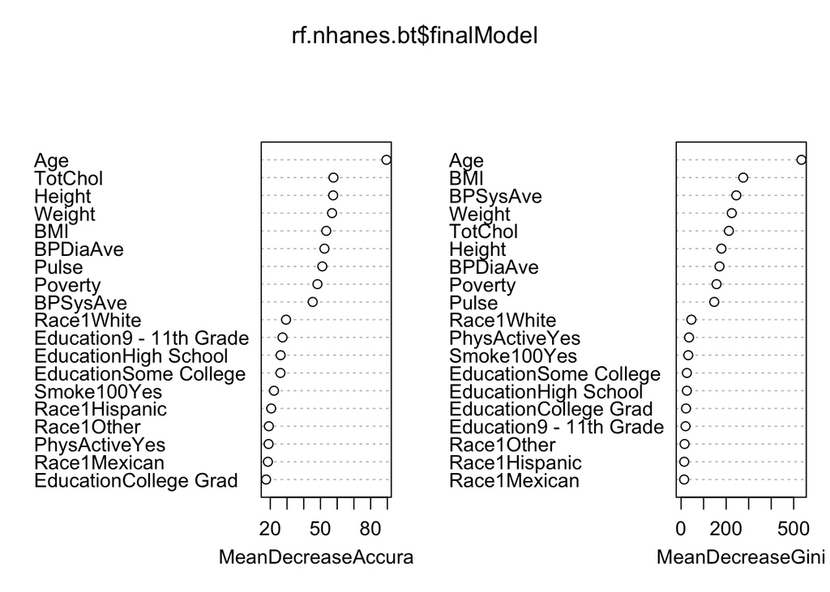

```r
varImpPlot(rf.nhanes.bt$finalModel)
```

### Model 2: Support Vector Classifier

```r
set.seed(123)

control.obj<-trainControl(method="cv", number=5, sampling="up", classProbs = TRUE)

#Repeat expanding the grid search
set.seed(123)

svc.nhanes<-train(Diabetes ~ ., data=train.data, method="svmLinear", trControl=control.obj, preProcess=c("center", "scale"), probability=TRUE, tuneGrid=expand.grid(C=seq(0.0001,100, length=10)))

svc.nhanes$bestTune
```

```
##         C
## 4 33.3334
```

```r
svc.nhanes$results
```

```
##           C  Accuracy     Kappa  AccuracySD    KappaSD
## 1    0.0001 0.7504726 0.2726347 0.020967977 0.02508331
## 2   11.1112 0.7515620 0.3033612 0.010225659 0.02021633
## 3   22.2223 0.7500907 0.3002407 0.006220660 0.02273034
## 4   33.3334 0.7534084 0.3059583 0.013377023 0.02958736
## 5   44.4445 0.7438367 0.2892485 0.008212017 0.01689901
## 6   55.5556 0.7519303 0.3026514 0.009923693 0.03363297
## 7   66.6667 0.7508294 0.3000580 0.015299909 0.02134595
## 8   77.7778 0.7486181 0.2940516 0.005702625 0.01842058
## 9   88.8889 0.7511971 0.2961792 0.009571362 0.03159936
## 10 100.0000 0.7534077 0.3002231 0.010479471 0.01893597
```

```r
confusionMatrix(svc.nhanes)
```

```
## Cross-Validated (5 fold) Confusion Matrix
##
## (entries are percentual average cell counts across resamples)
##
##           Reference
## Prediction   No  Yes
##        No  66.3  2.4
##        Yes 22.2  9.0
##
##  Accuracy (average) : 0.7534
```

### Model 3: Logistic Regression

```r
set.seed(123)

control.obj<-trainControl(method="cv", number=5, sampling="up")

logit.nhanes<-train(Diabetes~., data=train.data, method="glm", family="binomial",preProcess=c("center", "scale"), trControl=control.obj)

logit.nhanes$results
```

```
##   parameter  Accuracy     Kappa AccuracySD    KappaSD
## 1      none 0.7449443 0.2872659 0.01293007 0.01994497
```

```r
confusionMatrix(logit.nhanes)
```

```
## Cross-Validated (5 fold) Confusion Matrix
##
## (entries are percentual average cell counts across resamples)
##
##           Reference
## Prediction   No  Yes
##        No  65.7  2.7
##        Yes 22.8  8.8
##
##  Accuracy (average) : 0.7449
```

```r
coef(logit.nhanes$finalModel)
```

```
##               (Intercept)                       Age             Race1Hispanic
##             -0.0299598258              1.2711654901             -0.0019044612
##              Race1Mexican                Race1White                Race1Other
##              0.0779643578             -0.3066013994              0.2074473138
## `Education9 - 11th Grade`    `EducationHigh School`   `EducationSome College`
##             -0.1720856801             -0.1382293524              0.0035292225
##   `EducationCollege Grad`                   Poverty                    Weight
##             -0.0779982329             -0.2201333076             -1.8476597303
##                    Height                       BMI                     Pulse
##              1.0231555185              2.4774811814              0.2526903162
##                  BPSysAve                  BPDiaAve                   TotChol
##              0.1691937444              0.0011036880             -0.1933529959
##             PhysActiveYes               Smoke100Yes
##             -0.0009498227              0.2307703716
```

### Output predicted probabilities from each of the three models applied within the testing set.

```r
#Predict in test-set and output probabilities
rf.probs<-predict(rf.nhanes, test.data, type="prob")

#Pull out predicted probabilities for Diabetes=Yes
rf.pp<-rf.probs[,2]

svc.probs<-predict(svc.nhanes,test.data, type="prob")
svc.pp<-svc.probs[,2]

#Predict in test-set using response type
logit.probs<-predict(logit.nhanes, test.data, type="prob")
logit.pp<-logit.probs[,2]
```

### Plot and compare calibration curves across the three algorithms.

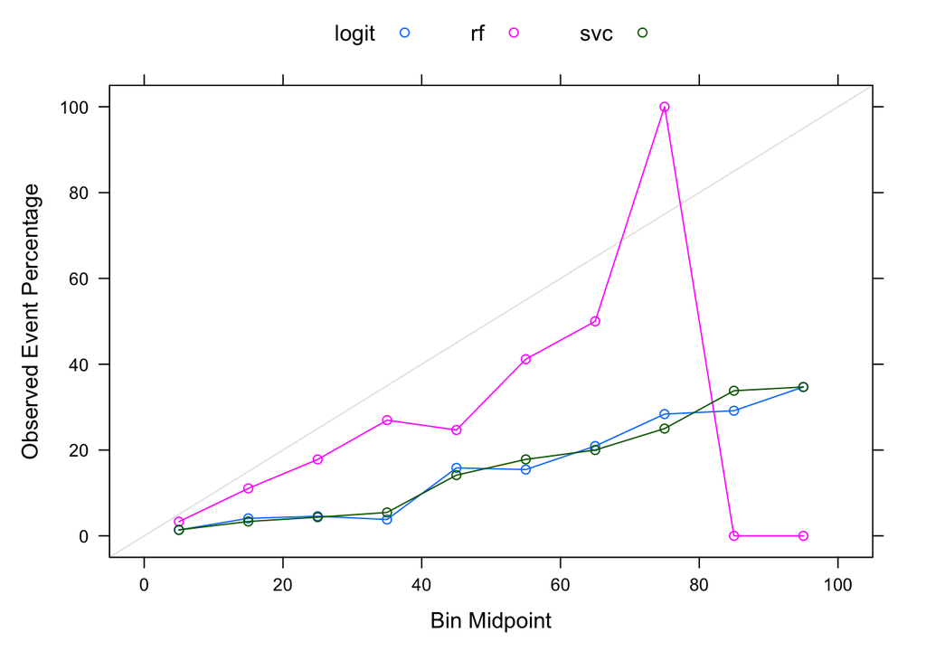

```r
pred.prob<-data.frame(Class=test.data$Diabetes, logit=logit.pp, rf=rf.pp, svc=svc.pp)

calplot<-(calibration(Class ~ logit+rf+svc, data=pred.prob, class="Yes", cuts=10))

xyplot(calplot, auto.key=list(columns=3))
```

### Calibrate the probabilities from SVC, RF, and Logistic Regression

Partition testing data into 2 sets: set to train calibration and then set to evaluate results

Method: Platt’s Scaling-train a logistic regression model on the outputs of your classifier

```r
set.seed(123)
cal.data.index<-test.data$Diabetes%>% createDataPartition(p=0.5, list=F)
cal.data<-test.data[cal.data.index, ]
final.test.data<-test.data[-cal.data.index, ]
```

#### Calibrating RF

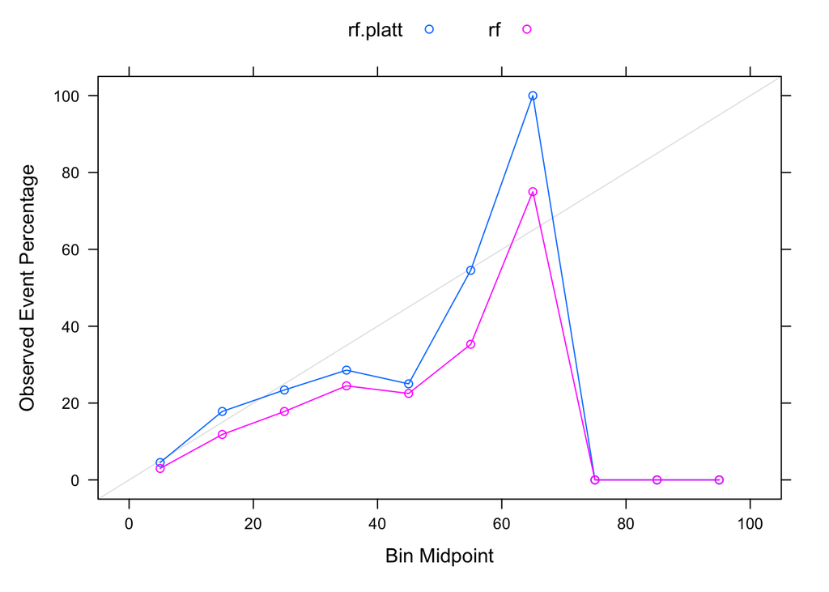

```r
#Predict on test-set without scaling to obtain raw pred prob in test set
rf.probs.nocal<-predict(rf.nhanes, final.test.data, type="prob")
rf.pp.nocal<-rf.probs.nocal[,2]

#Apply model developed on training data to calibration dataset to obtain predictions
rf.probs.cal<-predict(rf.nhanes, cal.data, type="prob")
rf.pp.cal<-rf.probs.cal[,2]

#Add to dataset with actual values from calibration data
calib.rf.data.frame<-data.frame(rf.pp.cal, cal.data$Diabetes)
colnames(calib.rf.data.frame)<-c("x", "y")

#Use logistic regression to model predicted probabilities from calibration data to actual vales
calib.rf.model<-glm(y ~ x, data=calib.rf.data.frame, family = binomial)

#Apply calibration model above to raw predicted probabilities from test set
data.test.rf<-data.frame(rf.pp.nocal)
colnames(data.test.rf)<-c("x")
platt.data.rf<-predict(calib.rf.model, data.test.rf, type="response")

platt.prob.rf<-data.frame(Class=final.test.data$Diabetes, rf.platt=platt.data.rf, rf=rf.pp.nocal)

calplot.rf<-(calibration(Class ~ rf.platt+rf, data=platt.prob.rf, class="Yes", cuts=10))
xyplot(calplot.rf, auto.key=list(columns=2))
```

#### Calibrating SVC

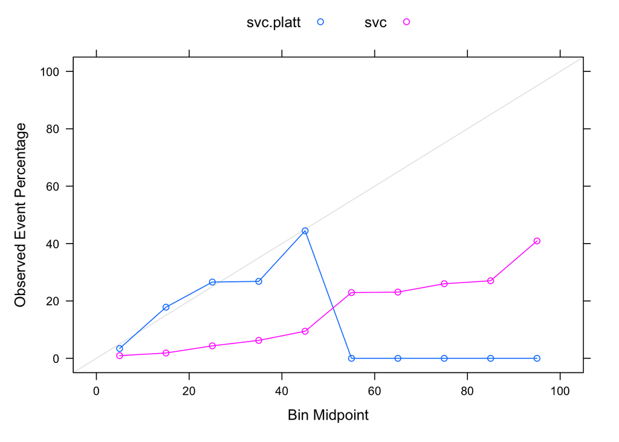

```r
#Predict on test-set without scaling
svc.probs.nocal<-predict(svc.nhanes,final.test.data, type="prob")
svc.pp.nocal<-svc.probs.nocal[,2]


#Apply model developed on training data to calibration dataset to obtain predictions
svc.probs.cal<-predict(svc.nhanes,cal.data, type="prob")
svc.pp.cal<-svc.probs.cal[,2]

#Add to dataset with actual values from calibration data
calib.svc.data.frame<-data.frame(svc.pp.cal, cal.data$Diabetes)
colnames(calib.svc.data.frame)<-c("x", "y")

#Use logistic regression to model predicted probabilities from calibration data to actual values
calib.svc.model<-glm(y ~ x, data=calib.svc.data.frame, family = binomial)

#Apply calibration model above to raw predicted probabilities from test set
data.test.svc<-data.frame(svc.pp.nocal)
colnames(data.test.svc)<-c("x")
platt.data.svc<-predict(calib.svc.model, data.test.svc, type="response")

platt.prob.svc<-data.frame(Class=final.test.data$Diabetes, svc.platt=platt.data.svc, svc=svc.pp.nocal)

calplot.svc<-(calibration(Class ~ svc.platt+svc, data=platt.prob.svc, class="Yes", cuts=10))
xyplot(calplot.svc, auto.key=list(columns=2))
```

#### Calibrating Logistic Regression

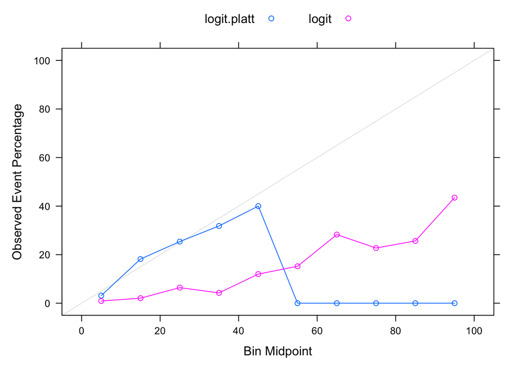

```r
#Predict on test-set without scaling to obtain raw pred prob in test set
logit.probs.nocal<- predict(logit.nhanes, final.test.data, type="prob")
logit.pp.nocal<- logit.probs.nocal[,2]

#Apply model developed on training data to calibration dataset to obtain predictions
logit.probs.cal<- predict(logit.nhanes, cal.data, type="prob")
logit.pp.cal<- logit.probs.cal[,2]

#Add to dataset with actual values from calibration data
calib.logit.data.frame<- data.frame(logit.pp.cal, cal.data$Diabetes)
colnames(calib.logit.data.frame)<-c("x", "y")

#Use logistic regression to model predicted probabilities from calibration data to actual values
calib.logit.model<- glm(y ~ x, data = calib.logit.data.frame, family = binomial)

#Apply calibration model above to raw predicted probabilities from test set
data.test.logit<- data.frame(logit.pp.nocal)
colnames(data.test.logit)<- c("x")
platt.data.logit<- predict(calib.logit.model, data.test.logit, type="response")

platt.prob.logit<- data.frame(Class = final.test.data$Diabetes, logit.platt = platt.data.logit, logit=logit.pp.nocal)

calplot.logit<-(calibration(Class ~ logit.platt+logit, data = platt.prob.logit, class = "Yes", cuts = 10))
xyplot(calplot.logit, auto.key = list(columns = 2))
```

### Optimal model

Based off of the three models above showing the pre and post calibration plots for all three algorithms, it is evident that none of the final models are “optimal”. An optimal model would demonstrate points along the line of the plot with a slope of 1 (i.e. the value along the x-axis (Bin Midpoint) is equal to the value along the y-axis (Observed Event Percentage)). This type of model would indicate that it was highly able to predict risk. However, the three models generated above demonstrates otherwise. The calibrated random forest model indicates that while it is good at estimating risk early on, it begins to over-estimate risk around 40% until 60% and then it demonstrates a high under-estimation of risk at 70%, then falling back down to an overestimation for the rest of the model. This would not be useful in a clinical setting. The calibrated SVC model indicates that it is quite good at estimating risk until 50%, it highly overestimates risk for the rest of the model. This is also observed in the calibrated logistic regression model. Ultimately, all of the three models would not be useful in a clinical setting, as it is only good at estimating risk for half of the model. Therefore, none of the models are “optimal”.

One additional evaluation I would perform if the goal was to implement this model within a clinical setting would be to increase the number of cross validations to see if the model would improve in its ability to predict risk. Increasing the number of cross validations may improve the model, allowing it to be implemented in clincal settings.